# Lab 10 - Grading the professor, Pt. 1

Modeling with a single predictor

Max Asmar

## Introduction

Many college courses conclude by giving students the opportunity to evaluate the course and the instructor anonymously. However, the use of these student evaluations as an indicator of course quality and teaching effectiveness is often criticized because these measures may reflect the influence of non-teaching related characteristics, such as the physical appearance of the instructor.

The article titled, “Beauty in the classroom: instructors’ pulchritude and putative pedagogical productivity” (Hamermesh and Parker, 2005) found that instructors who are viewed to be better looking receive higher instructional ratings. In this lab you will analyze the data from this study in order to learn what goes into a positive professor evaluation.

The data were gathered from end of semester student evaluations for a large sample of professors from the University of Texas at Austin. In addition, six students rated the professors’ physical appearance. The result is a data frame where each row contains a different course and columns represent variables about the courses and professors.

**Estimated time:** 90-120 minutes

## Learning Goals

By the end of this lab, you will be able to:

- Fit linear regression models with single numerical predictors
- Fit linear regression models with categorical predictors
- Interpret regression coefficients (slopes and intercepts) in context
- Calculate and interpret R-squared values
- Visualize regression lines on scatterplots
- Create and relevel categorical variables
- Compare models with different predictors
- Understand how reference levels affect interpretation

## Prerequisites

Before you begin, make sure you have:

- ✅ Completed Labs 01-09
- ✅ Watched lectures on linear regression and modeling
- ✅ Understand correlation and relationships between variables
- ✅ Forked the lab-instructions repository

# Getting Started

Navigate to your forked `lab-instructions` repository in JupyterHub, open the `Lab10` folder, and open the R Markdown document `lab-10.Rmd`.

## Verify Your Setup

Before proceeding:

Step 1. Open `lab-10.Rmd` in RStudio

Step 2. Check that the Git pane shows YOUR username (not the course organization)

Step 3. Click **Knit** to make sure the document compiles

## Warm Up

**Step 1:** Update the YAML, changing the author name to your name.

**Step 2:** Knit the document.

**Step 3:** Commit your changes with message “Updated author name”. Done.

**Step 4:** Push to GitHub and verify the changes are visible in your repo.

🧶 ✅ ⬆️ **Knit, commit with message “Completed warm up”, and push your changes.**

## Packages

We’ll use the **tidyverse** package for much of the data wrangling and visualisation, the **tidymodels** package for modeling and inference, and the data lives in the **openintro** package. These packages are already installed for you. You can load them by running the following in your Console:

```r
library(tidyverse)
library(tidymodels)
library(openintro)
```

## Data

The data can be found in the **openintro** package, and it’s called `evals`. Since the dataset is distributed with the package, we don’t need to load it separately; it becomes available to us when we load the package. You can find out more about the dataset by inspecting its documentation, which you can access by running `?evals` in the Console or using the Help menu in RStudio to search for `evals`. You can also find this information [here](https://www.openintro.org/data/index.php?data=evals).

**✓ Checkpoint:** Run `glimpse(evals)` in your Console to verify the data loaded correctly.

```r
    glimpse(evals)
```

```
## Rows: 463
## Columns: 23
## $ course_id     <int> 1, 2, 3, 4, 5, 6, 7, 8, 9, 10, 11, 12, 13, 14, 15, 16, 1…
## $ prof_id       <int> 1, 1, 1, 1, 2, 2, 2, 3, 3, 4, 4, 4, 4, 4, 4, 4, 4, 5, 5,…
## $ score         <dbl> 4.7, 4.1, 3.9, 4.8, 4.6, 4.3, 2.8, 4.1, 3.4, 4.5, 3.8, 4…
## $ rank          <fct> tenure track, tenure track, tenure track, tenure track, …
## $ ethnicity     <fct> minority, minority, minority, minority, not minority, no…
## $ gender        <fct> female, female, female, female, male, male, male, male, …
## $ language      <fct> english, english, english, english, english, english, en…
## $ age           <int> 36, 36, 36, 36, 59, 59, 59, 51, 51, 40, 40, 40, 40, 40, …
## $ cls_perc_eval <dbl> 55.81395, 68.80000, 60.80000, 62.60163, 85.00000, 87.500…
## $ cls_did_eval  <int> 24, 86, 76, 77, 17, 35, 39, 55, 111, 40, 24, 24, 17, 14,…
## $ cls_students  <int> 43, 125, 125, 123, 20, 40, 44, 55, 195, 46, 27, 25, 20, …
## $ cls_level     <fct> upper, upper, upper, upper, upper, upper, upper, upper, …
## $ cls_profs     <fct> single, single, single, single, multiple, multiple, mult…
## $ cls_credits   <fct> multi credit, multi credit, multi credit, multi credit, …
## $ bty_f1lower   <int> 5, 5, 5, 5, 4, 4, 4, 5, 5, 2, 2, 2, 2, 2, 2, 2, 2, 7, 7,…
## $ bty_f1upper   <int> 7, 7, 7, 7, 4, 4, 4, 2, 2, 5, 5, 5, 5, 5, 5, 5, 5, 9, 9,…
## $ bty_f2upper   <int> 6, 6, 6, 6, 2, 2, 2, 5, 5, 4, 4, 4, 4, 4, 4, 4, 4, 9, 9,…
## $ bty_m1lower   <int> 2, 2, 2, 2, 2, 2, 2, 2, 2, 3, 3, 3, 3, 3, 3, 3, 3, 7, 7,…
## $ bty_m1upper   <int> 4, 4, 4, 4, 3, 3, 3, 3, 3, 3, 3, 3, 3, 3, 3, 3, 3, 6, 6,…
## $ bty_m2upper   <int> 6, 6, 6, 6, 3, 3, 3, 3, 3, 2, 2, 2, 2, 2, 2, 2, 2, 6, 6,…
## $ bty_avg       <dbl> 5.000, 5.000, 5.000, 5.000, 3.000, 3.000, 3.000, 3.333, …
## $ pic_outfit    <fct> not formal, not formal, not formal, not formal, not form…
## $ pic_color     <fct> color, color, color, color, color, color, color, color, …
```

# Exercises

## Part 1: Exploratory Data Analysis

## Exercise 1

Visualize the distribution of `score`. Is the distribution skewed? What does that tell you about how students rate courses? Is this what you expected to see? Why, or why not? Include any summary statistics and visualizations you use in your response.

**Create a histogram:**

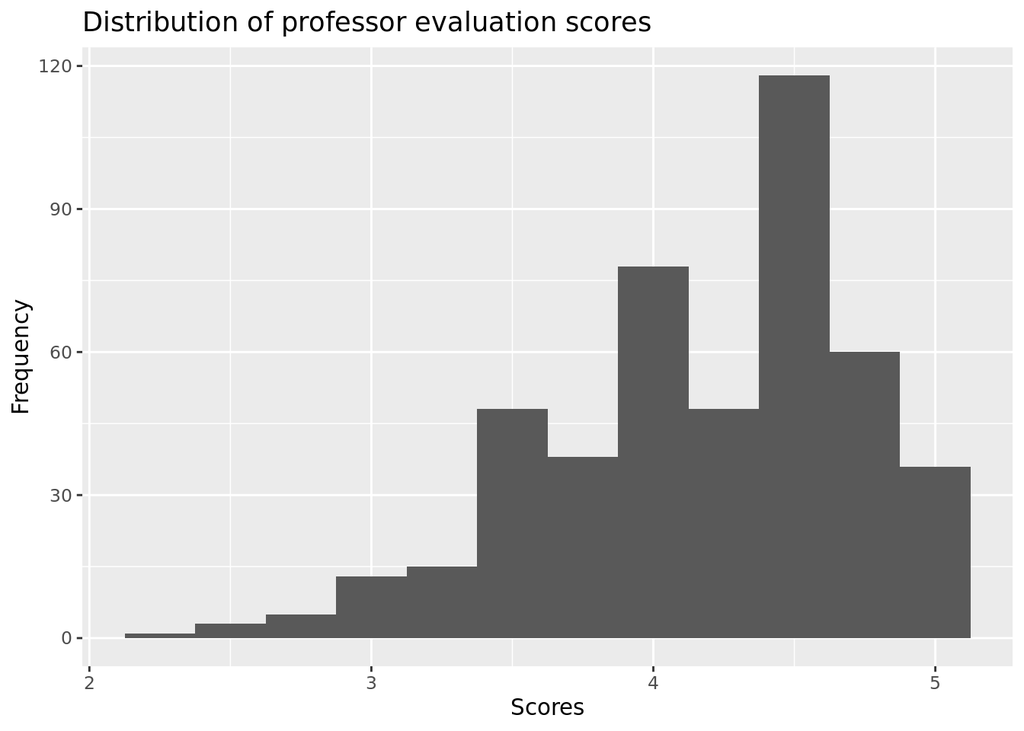

```r
# Remember to change eval=FALSE to eval=TRUE!
ggplot(data = evals, aes(x = score)) +
  geom_histogram(binwidth = 0.25) +
  labs(
    title = "Distribution of professor evaluation scores",
    x = "Scores",
    y = "Frequency"
  )
```

**Hint:** Try binwidths like 0.25 or 0.5 for scores.

**Calculate summary statistics:**

```r
# Remember to change eval=FALSE to eval=TRUE!
evals %>%
  summarise(
    min = min(score),
    q1 = quantile(score, 0.25),
    median = median(score),
    mean = mean(score),
    q3 = quantile(score, 0.75),
    max = max(score),
    sd = sd(score)
  )
```

```
## # A tibble: 1 × 7
##     min    q1 median  mean    q3   max    sd
##   <dbl> <dbl>  <dbl> <dbl> <dbl> <dbl> <dbl>
## 1   2.3   3.8    4.3  4.17   4.6     5 0.544
```

**Describe the distribution:**

**Shape (skewed left, skewed right, or symmetric?):**

The distribution of professor evaluation scores is skewed left.

**What does this tell you about how students rate courses?**

This tells me that students are more likely to rate courses closer to 5 stars.

**Is this what you expected? Why or why not?**

This is not what I expected. I expected that students would rate courses lower in general, closer to 3 stars because the survey is anonymous. I would expect the curve to follow a normal distribution centered at 3 stars, rather than a left skew.

## Exercise 2

Visualize and describe the relationship between `score` and `bty_avg`.

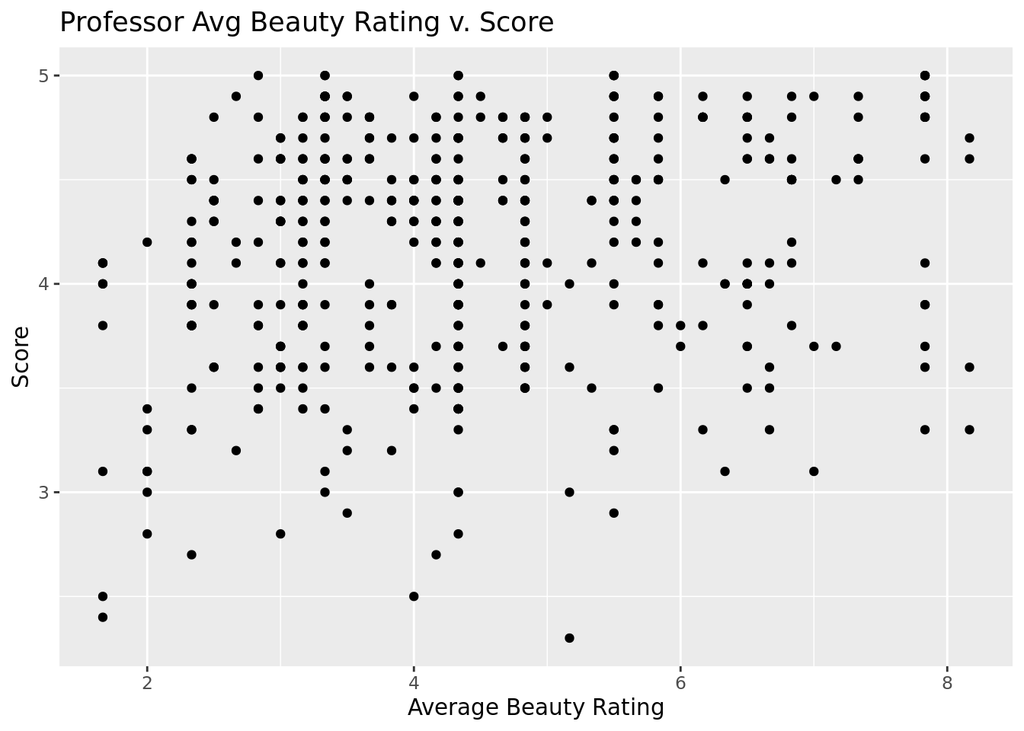

```r
# Remember to change eval=FALSE to eval=TRUE!
ggplot(data = evals, aes(x = bty_avg, y = score)) +
  geom_point() +
  labs(
    title = "Professor Avg Beauty Rating v. Score",
    x = "Average Beauty Rating",
    y = "Score"
  )
```

**Describe the relationship:**

**Direction (positive, negative, or no relationship):** Positive relationship

**Strength (weak, moderate, or strong):** Weak relationship

**Form (linear, curved, or no pattern):** No pattern.

**Are there any outliers?** No.

## Exercise 3

Recreate the scatterplot from Exercise 2, but this time use `geom_jitter()`. What does “jitter” mean? What was misleading about the initial scatterplot?

**Hint:** See the help page for the function at http://ggplot2.tidyverse.org/reference/index.html.

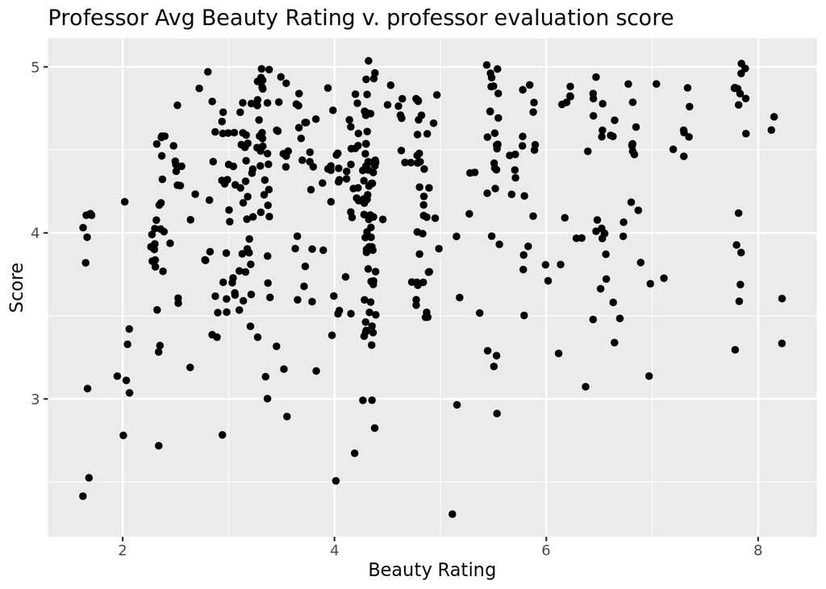

```r
# Remember to change eval=FALSE to eval=TRUE!
ggplot(data = evals, aes(x = bty_avg, y = score)) +
  geom_jitter() +
  labs(
    title = "Professor Avg Beauty Rating v. professor evaluation score",
    x = "Beauty Rating",
    y = "Score"
  )
```

**What does “jitter” mean?**

Jitter means to create a scatter plot, but to add random noise to the points because they might overlap.

**What was misleading about the initial scatterplot?**

The original scatterplot showed little to no correlation between beauty rating and professor evaluation score, but the new scatterplot spreads out the points through adding random noise and shows a weak positive association.

🧶 ✅ ⬆️ **Knit, commit with message “Completed Exercises 1-3”, and push your changes.**

## Part 2: Linear Regression with a Numerical Predictor

Linear model is in the form $\hat{y} = b_0 + b_1 x$.

## Exercise 4

Let’s see if the apparent trend in the plot is something more than natural variation. Fit a linear model called `score_bty_fit` to predict average professor evaluation `score` by average beauty rating (`bty_avg`). Based on the regression output, write the linear model.

**Fit the model:**

```r
# Remember to change eval=FALSE to eval=TRUE!
score_bty_fit <- linear_reg() %>%
  set_engine("lm") %>%
  fit(score ~ bty_avg, data = evals)

# View the results
tidy(score_bty_fit)
```

```
## # A tibble: 2 × 5
##   term        estimate std.error statistic   p.value
##   <chr>          <dbl>     <dbl>     <dbl>     <dbl>
## 1 (Intercept)   3.88      0.0761     51.0  1.56e-191
## 2 bty_avg       0.0666    0.0163      4.09 5.08e-  5
```

**Write the linear model equation:**

$$\widehat{score} = 3.88 + 0.067 \times bty\_avg$$

**Hint:** The intercept is the estimate for `(Intercept)` and the slope is the estimate for `bty_avg`.

## Exercise 5

Recreate the scatterplot from Exercise 2, and add the regression line to this plot in orange color, with shading for the uncertainty of the line turned off.

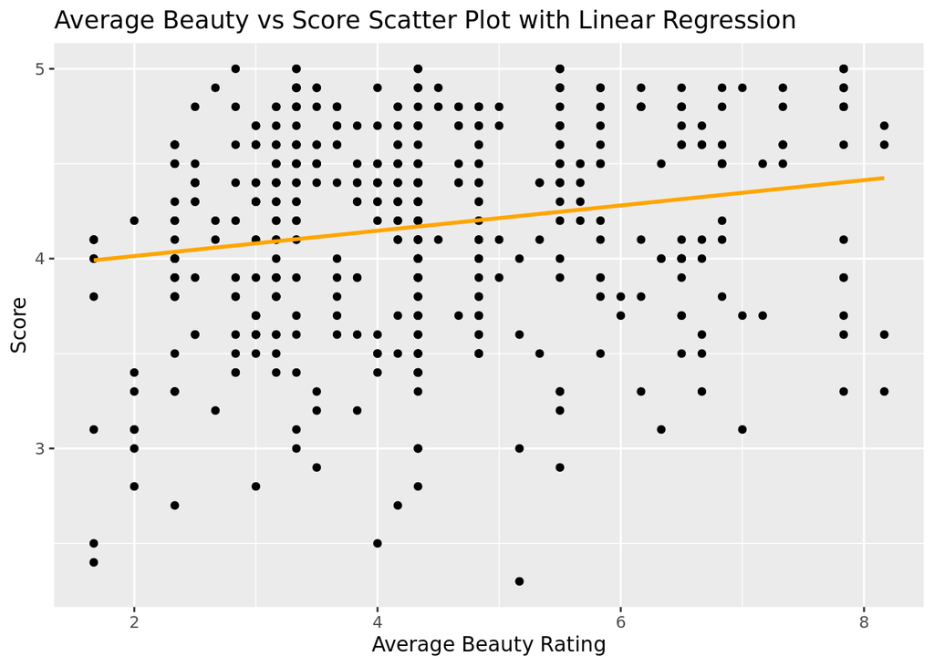

```r
# Remember to change eval=FALSE to eval=TRUE!
ggplot(data = evals, aes(x = bty_avg, y = score)) +
  geom_point() +
  geom_smooth(method = "lm", se = FALSE, color = "orange") +
  labs(
    title = "Average Beauty vs Score Scatter Plot with Linear Regression",
    x = "Average Beauty Rating",
    y = "Score"
  )
```

**Hints:**

- `method = "lm"` for linear model
- `se = FALSE` to turn off shading
- `color = "orange"` for orange line

## Exercise 6

Interpret the slope of the linear model in context of the data.

**The slope is:** 0.067 (get this from the tidy output)

**Interpretation in context:**

For every one star increase in average beauty rating, we expect the professor evaluation score to increase by 0.067 stars, on average.

**Template:** “For every one unit increase in [x variable], we expect [y variable] to [increase/decrease] by [slope value] units, on average.”

## Exercise 7

Interpret the intercept of the linear model in context of the data. Comment on whether or not the intercept makes sense in this context.

**The intercept is:** 3.88 stars (get this from the tidy output)

**Interpretation in context:**

When the beauty rating is 0, we expect the course rating to be 3.88 stars.

**Does this make sense in context? Why or why not?**

```r
# Remember to change eval=FALSE to eval=TRUE!
evals %>%
  summarise(min = min(bty_avg))
```

```
## # A tibble: 1 × 1
##     min
##   <dbl>
## 1  1.67
```

This does not make sense in context because the minimum average beauty rating is 1.67 stars. I think the y intercept is 3.88 stars because the lm model is curve fitting, without considering real world limitations, such as minimum stars.

**Hint:** Think about what a beauty rating of 0 means and whether it’s realistic.

## Exercise 8

Determine the R² of the model and interpret it in context of the data.

**Calculate R²:**

```r
# Remember to change eval=FALSE to eval=TRUE!
glance(score_bty_fit)
```

```
## # A tibble: 1 × 12
##   r.squared adj.r.squared sigma statistic   p.value    df logLik   AIC   BIC
##       <dbl>         <dbl> <dbl>     <dbl>     <dbl> <dbl>  <dbl> <dbl> <dbl>
## 1    0.0350        0.0329 0.535      16.7 0.0000508     1  -366.  738.  751.
## # ℹ 3 more variables: deviance <dbl>, df.residual <int>, nobs <int>
```

**The R² value is:** 0.035 (look for `r.squared` in the output)

**Interpretation in context:**

Approximately 3.5% of the variability in professor evaluation scores is explained by their average beauty rating.

🧶 ✅ ⬆️ **Knit, commit with message “Completed Exercises 4-8”, and push your changes.**

## Part 3: Linear Regression with a Categorical Predictor

## Exercise 9

Fit a new linear model called `score_gender_fit` to predict average professor evaluation `score` based on `gender` of the professor. Based on the regression output, write the linear model and interpret the slope and intercept in context of the data.

**Fit the model:**

```r
# Remember to change eval=FALSE to eval=TRUE!
score_gender_fit <- linear_reg() %>%
  set_engine("lm") %>%
  fit(score ~ gender, data = evals)

tidy(score_gender_fit)
```

```
## # A tibble: 2 × 5
##   term        estimate std.error statistic p.value
##   <chr>          <dbl>     <dbl>     <dbl>   <dbl>
## 1 (Intercept)    4.09     0.0387    106.   0
## 2 gendermale     0.142    0.0508      2.78 0.00558
```

**Write the linear model equation:**

$$\widehat{score} = 4.09 + 0.142 \times gendermale$$

**Note:** R uses the first category alphabetically as the reference (baseline) level. So “female” is the reference here.

**Interpret the intercept:**

When the Professor is female, the average professor evaluation score is expected to be 4.09 stars.

**Interpret the slope:**

When the professor is male, we expect the average professor evaluation score to increase by 0.142 stars, on average.

## Exercise 10

What is the equation of the line corresponding to male professors? What is it for female professors?

**For male professors (where gender = male, so gendermale = 1):**

$$\widehat{score} = 4.09 + 0.142 \times 1 = 4.232$$

**For female professors (where gender = female, so gendermale = 0):**

$$\widehat{score} = 4.09 + 0.142 \times 0 = 4.09$$

**What does this tell you about the difference in average scores?**

This tells me that the difference in professor evaluation scores between male and female professors is 0.142 stars, where male professors have higher average scores.

🧶 ✅ ⬆️ **Knit, commit with message “Completed Exercises 9-10”, and push your changes.**

## Exercise 11

Fit a new linear model called `score_rank_fit` to predict average professor evaluation `score` based on `rank` of the professor. Based on the regression output, write the linear model and interpret the slopes and intercept in context of the data.

**Fit the model:**

```r
# Remember to change eval=FALSE to eval=TRUE!
score_rank_fit <- linear_reg() %>%
  set_engine("lm") %>%
  fit(score ~ rank, data = evals)

tidy(score_rank_fit)
```

```
## # A tibble: 3 × 5
##   term             estimate std.error statistic   p.value
##   <chr>               <dbl>     <dbl>     <dbl>     <dbl>
## 1 (Intercept)         4.28     0.0537     79.9  1.02e-271
## 2 ranktenure track   -0.130    0.0748     -1.73 8.37e-  2
## 3 ranktenured        -0.145    0.0636     -2.28 2.28e-  2
```

**Note:** `rank` has three categories: teaching, tenure track, and tenured. R will use the first alphabetically as reference.

**Write the linear model equation:**

$$\widehat{score} = 4.28 + (-0.13) \times ranktenuretrack + (-0.145) \times ranktenured$$

**Interpret the intercept (for teaching faculty):**

When the teacher is not tenured or not on a tenure track, the average professor evaluation score is expected to be 4.28.

**Interpret the slope for ranktenuretrack:**

When the teacher is on the tenure track, we expect the average professor evaluation score to decrease by 0.13 stars, on average.

**Interpret the slope for ranktenured:**

When the teacher is tenured, we expect the average professor evaluation score to decrease by 0.145 stars, on average.

## Exercise 12

Create a new variable called `rank_relevel` where “tenure track” is the baseline level.

```r
# Remember to change eval=FALSE to eval=TRUE!
evals <- evals %>%
  mutate(rank_relevel = fct_relevel(rank, "tenure track"))
```

**What this does:**

- `fct_relevel()` changes which category is the reference level
- Put “tenure track” as the first argument to make it the baseline

**Verify it worked:**

```r
# Remember to change eval=FALSE to eval=TRUE!
levels(evals$rank_relevel)
```

```
## [1] "tenure track" "teaching"     "tenured"
```

The first level shown should be “tenure track”.

## Exercise 13

Fit a new linear model called `score_rank_relevel_fit` to predict average professor evaluation `score` based on `rank_relevel` of the professor. This is the new (releveled) variable you created in Exercise 12. Based on the regression output, write the linear model and interpret the slopes and intercept in context of the data. Also determine and interpret the R² of the model.

**Fit the model:**

```r
# Remember to change eval=FALSE to eval=TRUE!
score_rank_relevel_fit <- linear_reg() %>%
  set_engine("lm") %>%
  fit(score ~ rank_relevel, data = evals)

tidy(score_rank_relevel_fit)
```

```
## # A tibble: 3 × 5
##   term                 estimate std.error statistic   p.value
##   <chr>                   <dbl>     <dbl>     <dbl>     <dbl>
## 1 (Intercept)            4.15      0.0521    79.7   2.58e-271
## 2 rank_relevelteaching   0.130     0.0748     1.73  8.37e-  2
## 3 rank_releveltenured   -0.0155    0.0623    -0.249 8.04e-  1
```

```r
glance(score_rank_relevel_fit)
```

```
## # A tibble: 1 × 12
##   r.squared adj.r.squared sigma statistic p.value    df logLik   AIC   BIC
##       <dbl>         <dbl> <dbl>     <dbl>   <dbl> <dbl>  <dbl> <dbl> <dbl>
## 1    0.0116       0.00733 0.542      2.71  0.0679     2  -372.  752.  768.
## # ℹ 3 more variables: deviance <dbl>, df.residual <int>, nobs <int>
```

**Write the linear model equation:**

$$\widehat{score} = 4.15 + 0.13 \times rankreleveltea ching + (-0.016) \times rankreleveltenured$$

**Interpret the intercept (now for tenure track faculty):**

When the teacher is on the tenure track, they are expected to have an average professor evaluation score of 4.15 stars.

**Interpret the slopes:**

The rankrelevelteaching coefficient slope represents that when the teacher is not tenured, we expect the average professor evaluation score to increase by 0.13 stars, on average. The rankreleveltenured coefficient slope represents that when the teacher is tenured, we expect the average professor evaluation score to decrease by 0.016 stars, on average.

**R² value:** 0.0116

**Interpretation of R²:**

Approximately 1.16% of the variability in professor evaluation scores is explained by their tenure track.

🧶 ✅ ⬆️ **Knit, commit with message “Completed Exercises 11-13”, and push your changes.**

## Exercise 14

Create another new variable called `tenure_eligible` that labels “teaching” faculty as “no” and labels “tenure track” and “tenured” faculty as “yes”.

```r
# Remember to change eval=FALSE to eval=TRUE!
evals <- evals %>%
  mutate(tenure_eligible = if_else(
    rank == "teaching",
    "no",
    "yes"
  ))
```

**Hints:** - If rank equals “teaching”, set to “no” - Otherwise, set to “yes”

**Verify it worked:**

```r
# Remember to change eval=FALSE to eval=TRUE!
evals %>%
  count(rank, tenure_eligible)
```

```
## # A tibble: 3 × 3
##   rank         tenure_eligible     n
##   <fct>        <chr>           <int>
## 1 teaching     no                102
## 2 tenure track yes               108
## 3 tenured      yes               253
```

You should see teaching faculty labeled as “no” and the other two as “yes”.

## Exercise 15

Fit a new linear model called `score_tenure_eligible_fit` to predict average professor evaluation `score` based on `tenure_eligible`ness of the professor. This is the new (regrouped) variable you created in the previous exercise. Based on the regression output, write the linear model and interpret the slopes and intercept in context of the data. Also determine and interpret the R² of the model.

**Fit the model:**

```r
# Remember to change eval=FALSE to eval=TRUE!
score_tenure_eligible_fit <- linear_reg() %>%
  set_engine("lm") %>%
  fit(score ~ tenure_eligible, data = evals)

tidy(score_tenure_eligible_fit)
```

```
## # A tibble: 2 × 5
##   term               estimate std.error statistic   p.value
##   <chr>                 <dbl>     <dbl>     <dbl>     <dbl>
## 1 (Intercept)           4.28     0.0536     79.9  2.72e-272
## 2 tenure_eligibleyes   -0.141    0.0607     -2.32 2.10e-  2
```

```r
glance(score_tenure_eligible_fit)
```

```
## # A tibble: 1 × 12
##   r.squared adj.r.squared sigma statistic p.value    df logLik   AIC   BIC
##       <dbl>         <dbl> <dbl>     <dbl>   <dbl> <dbl>  <dbl> <dbl> <dbl>
## 1    0.0115       0.00935 0.541      5.36  0.0210     1  -372.  750.  762.
## # ℹ 3 more variables: deviance <dbl>, df.residual <int>, nobs <int>
```

**Write the linear model equation:**

$$\widehat{score} = 4.28 + (-0.141) \times tenureeligibleyes$$

**Interpret the intercept:**

The intercept means that when the faculty is not tenure eligible, their average professor evaluation score is expected to be 4.28 stars.

**Interpret the slope:**

The slope represents that when the teacher is tenure eligible, we expect the average professor evaluation score to decrease by 0.141 stars, on average.

**R² value:** 0.0115

**Interpretation of R²:**

Approximately 1.15% of the variability in professor evaluation scores is explained by their tenure eligibility.

**How does this R² compare to the R² from Exercise 13? What does this tell you?**

This R^2 value is basically equivalent to the R^2 value from Exercise 13. This tells me that the professor’s tenure eligibility explains the same level of variation in professor evaulation scores as the professor’s rank.

🧶 ✅ ⬆️ **Knit, commit with message “Completed Exercises 14-15”, and push your changes.**

## Common Errors and Troubleshooting

**Modeling errors:**

- **Error: “could not find function ‘linear_reg’”** → Load tidymodels: `library(tidymodels)`
- **Error: “object not found”** → Make sure you created and saved the new variables with `<-`
- **Model output shows NA** → Check that variables exist and have valid data

**Interpretation errors:**

- **Confused about reference levels** → Run `levels(evals$variable)` to see which is first (reference)
- **Intercept doesn’t make sense** → That’s okay! Not all intercepts are meaningful
- **Negative R²** → This shouldn’t happen; check your model specification

**Variable creation errors:**

- **`fct_relevel()` not working** → Make sure the variable is a factor first
- **`if_else()` creating NAs** → Check your condition logic
- **Can’t find new variable** → Make sure you saved it back to `evals` with `<-`

**Visualization errors:**

- **Regression line not showing** → Make sure `method = "lm"` in `geom_smooth()`
- **Points overlap** → Use `geom_jitter()` instead of `geom_point()`

**General issues:**

- **Code chunk not running** → Make sure you changed `eval=FALSE` to `eval=TRUE`
- **Can’t interpret coefficient** → Remember context: what do units mean?

**To submit to Canvas:**

Step 1. In RStudio, click the **Knit** dropdown menu (next to the Knit button)

Step 2. Select **Knit to tufte_handout** to generate a PDF

Step 3. Download the PDF file from the Files pane

Step 4. Upload the PDF to Canvas

**✓ Final Checkpoint:** Visit your GitHub repo one more time to confirm all your work is there. We will grade what we see in your repo on GitHub!